# Exercise 05

Jennie

2024-03-01

# Challenge 1

## Step 1

- Using the {tidyverse} `read_csv()` function, load the “IMDB-movies.csv” dataset from [this URL](https://raw.githubusercontent.com/difiore/ada-2024-datasets/main/IMDB-movies.csv) as a “tibble” named **d**

```r
library(tidyverse)
d <- read_csv("https://raw.githubusercontent.com/difiore/ada-2024-datasets/main/IMDB-movies.csv")
as_tibble(d)
```

```
## # A tibble: 28,938 × 10
##    tconst   titleType primaryTitle startYear runtimeMinutes genres averageRating
##    <chr>    <chr>     <chr>            <dbl>          <dbl> <chr>          <dbl>
##  1 tt00021… movie     Dante's Inf…      1911             68 Adven…           7
##  2 tt00028… movie     Fantômas: I…      1913             54 Crime…           7
##  3 tt00030… movie     Fantomas: T…      1913             61 Crime…           7
##  4 tt00031… movie     Fantômas: T…      1913             90 Crime…           7
##  5 tt00034… movie     The Student…      1913             85 Drama…           6.5
##  6 tt00036… movie     The Avengin…      1914             78 Crime…           6.5
##  7 tt00037… movie     Cabiria           1914            148 Adven…           7.1
##  8 tt00039… movie     Fantomas: T…      1914             59 Crime…           6.9
##  9 tt00041… movie     Judith of B…      1914             61 Drama            6.2
## 10 tt00047… movie     Tillie's Pu…      1914             82 Comedy           6.3
## # ℹ 28,928 more rows
## # ℹ 3 more variables: numVotes <dbl>, nconst <chr>, director <chr>
```

## Step 2

- Use a one-line statement to filter the dataset to include just movies from 1920 to 1979 and movies that are between 1 and 3 hours long (**runtimeMinutes** >= 60 and **runtimeMinutes** <= 180), and add a new column that codes the **startYear** into a new variable, **decade** (“20s”, “30s”, …“70s”). If you do this correctly, there should be 5651 movies remaining in the dataset.

```r
library(dplyr)
d <- d |> filter(runtimeMinutes>=60 & runtimeMinutes<=180) |> filter(startYear>=1920 & startYear<=1979) |> mutate(Decade = if_else(startYear >= 2000, paste0(startYear  %/% 10 * 10, "s"), paste0((startYear - 1900) %/% 10 * 10, "s")))
```

## Step 3

- Use {ggplot2} (which is part of {tidyverse}) to plot histograms of the distribution of **runtimeMinutes** for each decade.

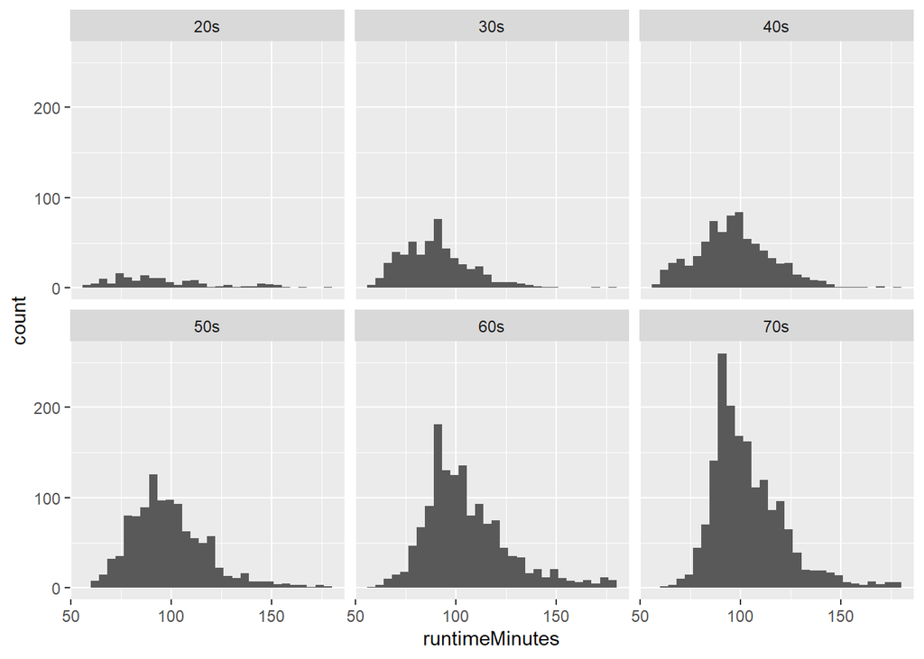

```r
library(ggplot2)
plots <- ggplot(d, aes(x=runtimeMinutes)) +
  geom_histogram()
plots + facet_wrap(vars(Decade), nrow = 2)
```

## Step 4

- Use a one-line statement to calculate the population mean and population standard deviation in **runtimeMinutes** for each decade and save the results in a new dataframe called **results**.

```r
results <- d |> group_by(Decade) |> summarize(mean = mean(runtimeMinutes), sd = sd(runtimeMinutes))
```

## Step 5

- Draw a single sample of 100 movies, without replacement, from each decade and calculate the single sample mean and single sample standard deviation in **runtimeMinutes** for each decades. Recall that your single sample mean for each decade is an *estimate* of the population mean for each decade.

```r
d_sample <- d |> group_by(Decade) |> slice_sample(n = 100, replace = FALSE)
d_sample_summary <- d_sample |> summarize(mean = mean(runtimeMinutes), sd = sd(runtimeMinutes))
```

## Step 6

- Calculate for each decade the standard error around your estimate of the population mean **runtimeMinutes** based on the standard deviation and sample size (n=100 movies) of your single sample.

```r
d_sample_summary$se <- (d_sample_summary$sd/sqrt(100))
```

## Step 7

- Compare these estimates to the actual population mean **runtimeMinutes** for each decade and to the calculated SE in the population mean for samples of size 100 based on the population standard deviation for each decade.

```r
# difference in population and sample means
d_sample_summary$mean_diff <- (results$mean - d_sample_summary$mean)

# SE from pop is population sd divided by sample size
d_sample_summary$se_pop <- (results$sd/sqrt(100))

# difference in SE
d_sample_summary$se_diff <- (d_sample_summary$se_pop - d_sample_summary$se)
```

## Step 8

- Generate a *sampling distribution* of mean **runtimeMinutes** for each decade by [a] drawing 1000 random samples of 100 movies from each decade, without replacement, and, for each sample, [b] calculating the mean **runtimeMinutes** and the standard deviation in **runtimeMinutes** for each decade. Use either a standard `for( ){ }` loop, the `do(reps) *` formulation from {mosaic}, the `rerun()` function from {purrr}, or the `rep_sample_n()` workflow from {infer} to generate your these sampling distributions (see [**Module 16**](https://difiore.github.io/ada-2024/16-module.html)).

```r
library(infer)
reps <- 1000
# make a sampling distribution
samp_dist_decade <- d |> group_by(Decade) |> rep_sample_n(size = 100, reps = reps, replace = FALSE)
# summarize by decade (and by replicate, so there's like 1000 means and SDs)
sample_dist_summary <- samp_dist_decade |> group_by(replicate, Decade) |> summarize(mean = mean(runtimeMinutes), sd = sd(runtimeMinutes))
```

## Step 9

- Then, calculate the **mean** and the **standard deviation** of the sampling distribution of sample means for each decade (the former should be a very good estimate of the population mean, while the latter is another estimate of the standard error in our estimate of the population mean for a particular sample size) and plot a histogram of the sampling distribution for each decade. What shape does it have?

The shape is that of a normal distribution, but very narrow for all decades after the 1920s.

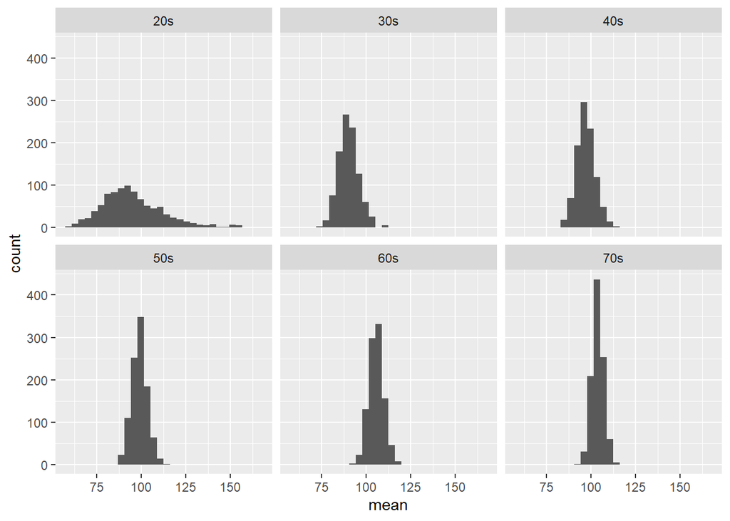

```r
# calculate the mean and SD of the means for each decade
step9 <- sample_dist_summary |> group_by(Decade) |> filter(!is.na(mean)) |> summarise(mean = mean(sample_dist_summary$mean), sd = sd(sample_dist_summary$mean))
# plot a histogram of the sampling distribution for each decade
plots2 <- ggplot(sample_dist_summary, aes(x=mean)) +
  geom_histogram()
plots2 + facet_wrap(vars(Decade), nrow = 2)
```

```r
# the shape is that of a normal distribution, but very narrow for all decades except 20s.
```

## Step 10

- Finally, compare the standard error in **runtimeMinutes** for samples of size 100 from each decade [1] as estimated from your **first** sample of 100 movies, [2] as calculated from the known *population* standard deviations for each decade, and [3] as estimated from the sampling distribution of sample means for each decade.

```r
# [1] Standard error per decade from first sample
step10.1 <- d_sample_summary$se
# [2] Standard error from the known population
step10.2 <- d_sample_summary$se_pop
# [3] Standard error from the sampling distribution
step10.3 <- (step9$sd/sqrt(100))
```

# Challenge 2

## Step 1

- Using the {tidyverse} `read_csv()` function, load the “zombies.csv” dataset from [this URL](https://raw.githubusercontent.com/difiore/ada-2024-datasets/main/zombies.csv) as a “tibble” named **z**. This dataset includes the first and last name and gender of the **entire** population of 1000 people who have survived the zombie apocalypse and are now ekeing out an existence somewhere on the Gulf Coast, along with several other variables (height, weight, age, number of years of education, number of zombies they have killed, and college major).

```r
z <- read_csv("https://raw.githubusercontent.com/difiore/ada-2024-datasets/main/zombies.csv")
as_tibble(z)
```

```
## # A tibble: 1,000 × 10
##       id first_name last_name gender height weight zombies_killed
##    <dbl> <chr>      <chr>     <chr>   <dbl>  <dbl>          <dbl>
##  1     1 Sarah      Little    Female   62.9   132.              2
##  2     2 Mark       Duncan    Male     67.8   146.              5
##  3     3 Brandon    Perez     Male     72.1   153.              1
##  4     4 Roger      Coleman   Male     66.8   130.              5
##  5     5 Tammy      Powell    Female   64.7   132.              4
##  6     6 Anthony    Green     Male     71.2   153.              1
##  7     7 Theresa    Hamilton  Female   70.3   160.              0
##  8     8 Phyllis    Jenkins   Female   59.8   109.              4
##  9     9 Steven     Long      Male     68.6   153.              9
## 10    10 Russell    Chavez    Male     72.8   169.              2
## # ℹ 990 more rows
## # ℹ 3 more variables: years_of_education <dbl>, major <chr>, age <dbl>
```

## Step 2

- Calculate the *population* mean and standard deviation for each quantitative random variable in the dataset (height, weight, age, number of zombies killed, and years of education).

> **NOTE:** You will **not** want to use the built in `var()` and `sd()` commands as those are for *samples*.

```r
# pop mean
z.mean.height <- mean(z$height)
z.mean.weight <- mean(z$weight)
z.mean.age <- mean(z$age)
z.mean.zombies <- mean(z$zombies_killed)
# pop sd
z.sd.height <- sqrt(sum((z$height - mean(z$height))^2)/length(z$height))
z.sd.weight <- sqrt(sum((z$weight - mean(z$weight))^2)/length(z$weight))
z.sd.age <- sqrt(sum((z$age - mean(z$age))^2)/length(z$age))
z.sd.zombies <- sqrt(sum((z$zombies_killed - mean(z$zombies_killed))^2)/length(z$zombies_killed))
```

## Step 3

- Use {ggplot} and make boxplots of each of these variables by gender.

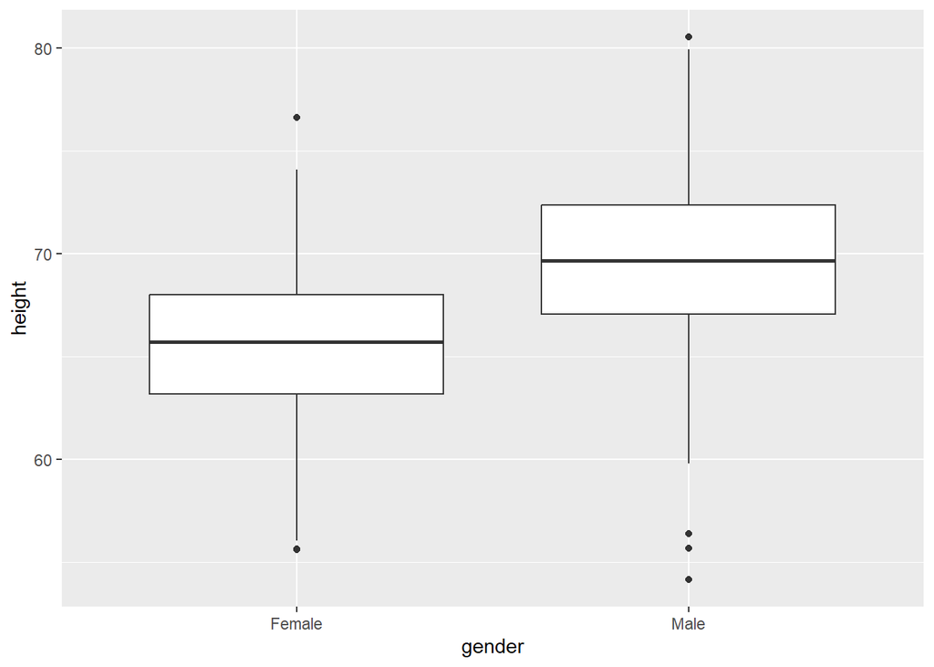

```r
plots3.1 <- ggplot(z, aes(x=gender, y=height)) + geom_boxplot()
plots3.1
```

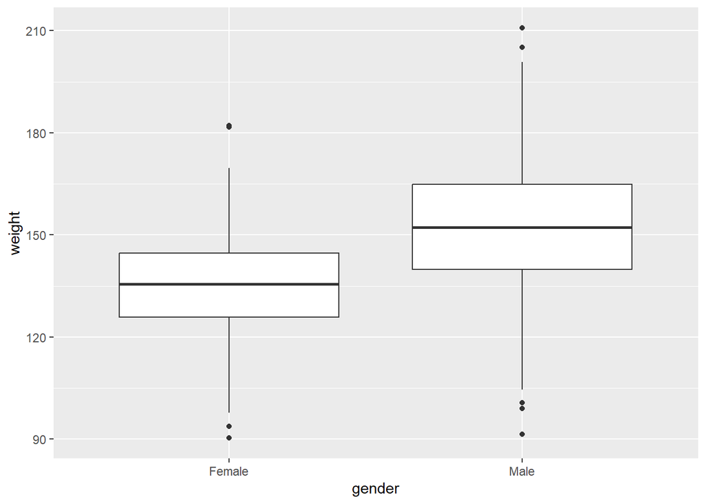

```r
plots3.2 <- ggplot(z, aes(x=gender, y=weight)) + geom_boxplot()
plots3.2
```

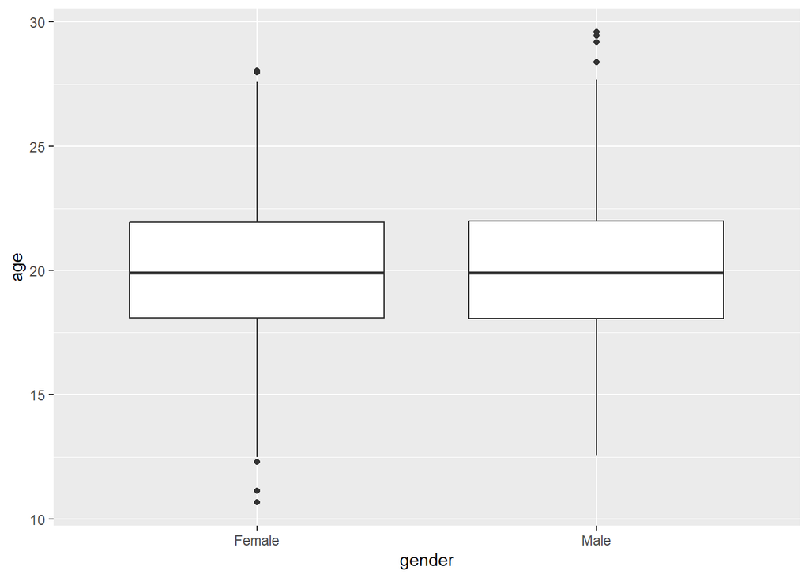

```r
plots3.3 <- ggplot(z, aes(x=gender, y=age)) + geom_boxplot()
plots3.3
```

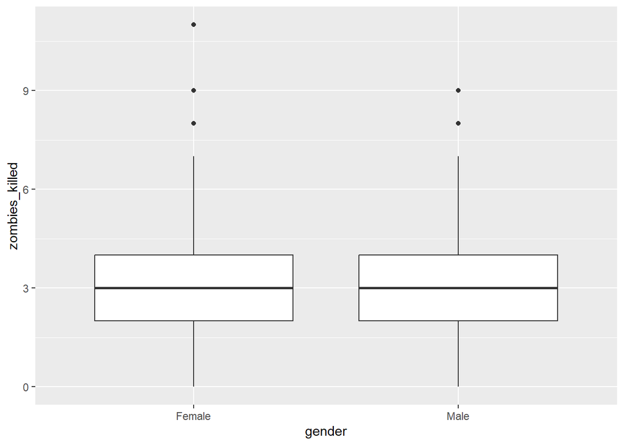

```r
plots3.4 <- ggplot(z, aes(x=gender, y=zombies_killed)) + geom_boxplot()
plots3.4
```

## Step 4

- Use {ggplot} and make scatterplots of height and weight in relation to age (i.e., use age as the x variable), using different colored points for males versus females. Do these variables seem to be related? In what way?

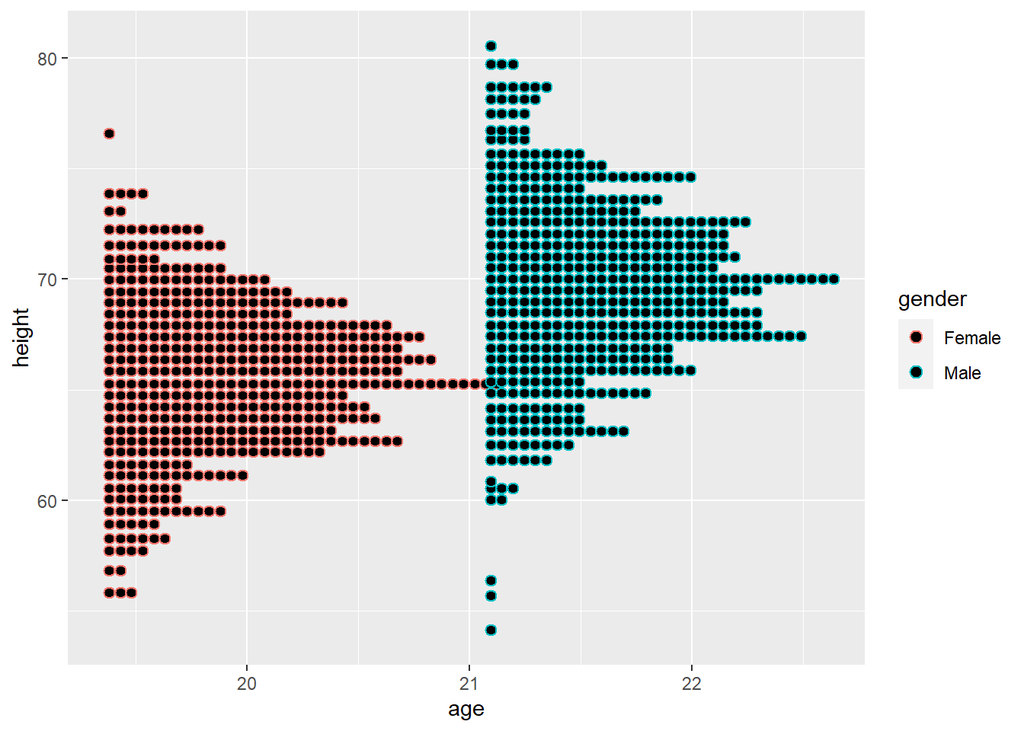

```r
plots4.1h <- ggplot(z, aes(x=age, y=height, color=gender)) + geom_dotplot(binaxis = "y", binwidth = 0.5)
plots4.1h
```

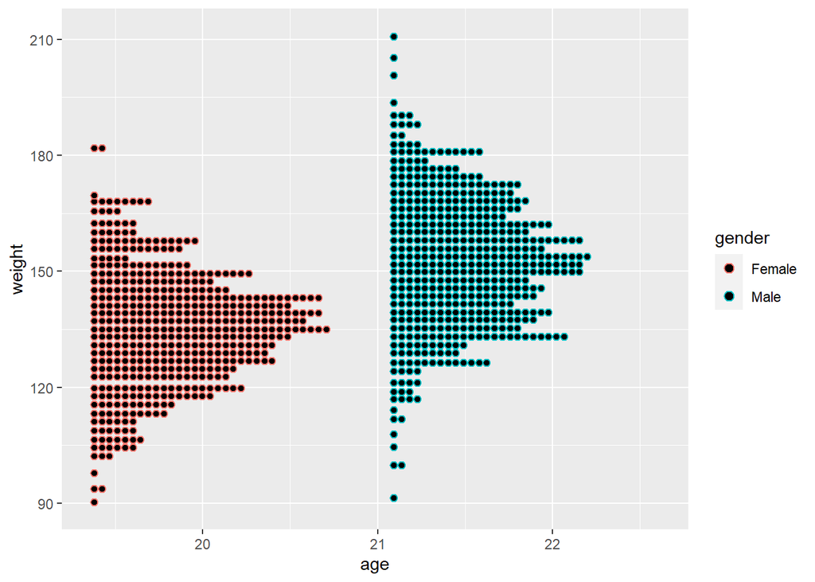

```r
plots4.1w <- ggplot(z, aes(x=age, y=weight, color=gender)) + geom_dotplot(binaxis = "y", binwidth = 2)
plots4.1w
```

## Step 5

- Using histograms and Q-Q plots, check whether each of the quantitative variables seem to be drawn from a normal distribution. Which seem to be and which do not?

> **HINT:** Not all are drawn from a normal distribution! For those that are not, can you determine what common distribution they are drawn from?

Height, weight, and age follow a mostly normal distribution, with the majority of dots aligning in the Q-Q plots except for those at the ends. Years of education and number of zombies killed are not continuous variables, which narrows down the distribution types to Bernoulli, binomial, and poisson.

```r
library("car")
```

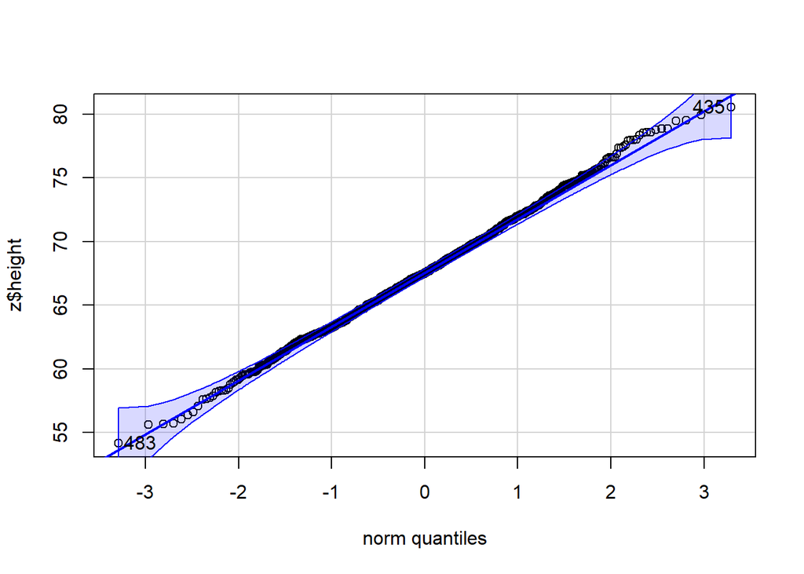

```
## [1] 483 435
```

```r
# height
qqPlot(z$height)
```

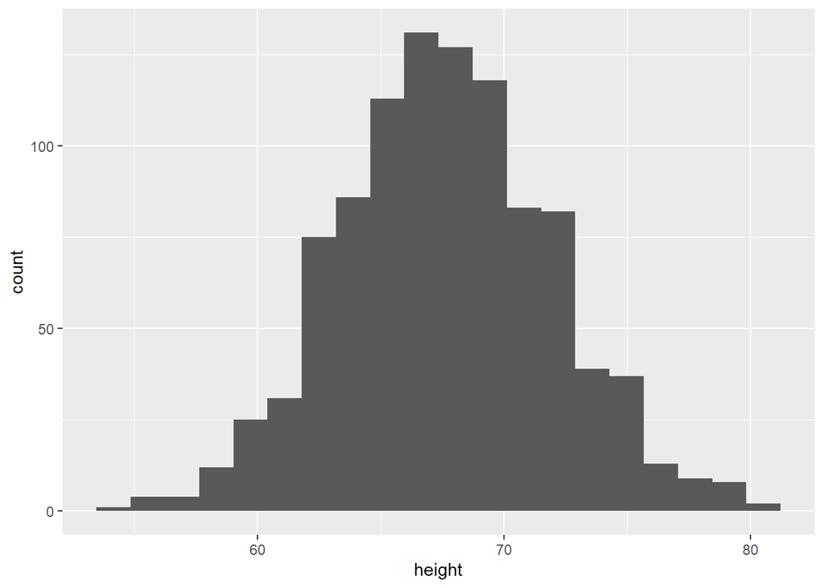

```r
ggplot(z, aes(x=height)) + geom_histogram(bins = 20)
```

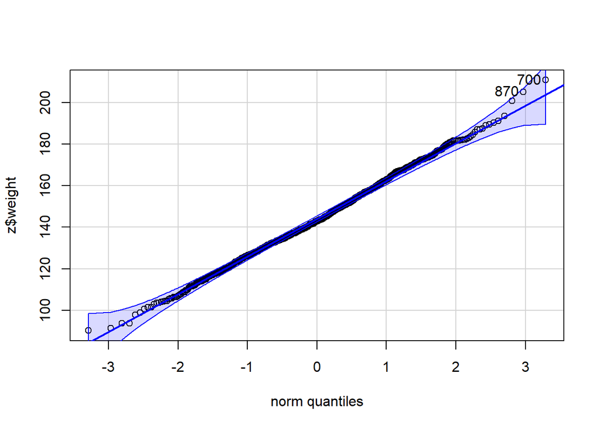

```
## [1] 700 870
```

```r
# weight
qqPlot(z$weight)
```

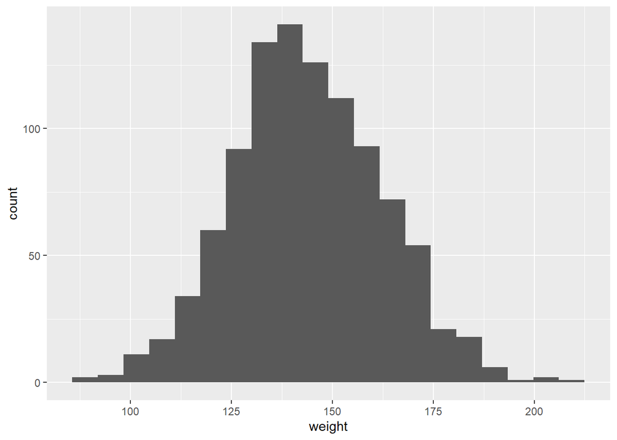

```r
ggplot(z, aes(x=weight)) + geom_histogram(bins = 20)
```

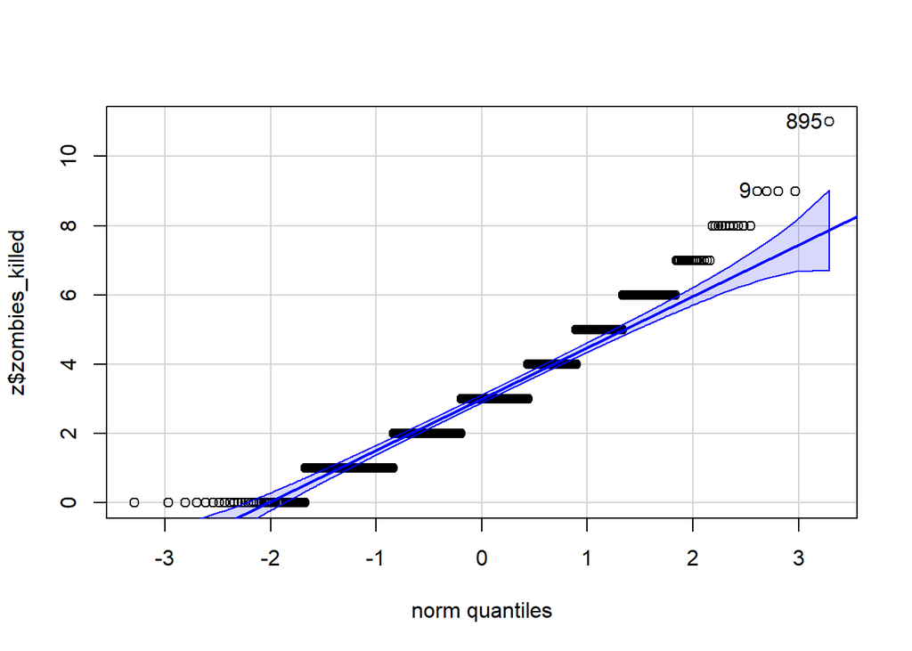

```
## [1] 895   9
```

```r
# zombies killed
qqPlot(z$zombies_killed)
```

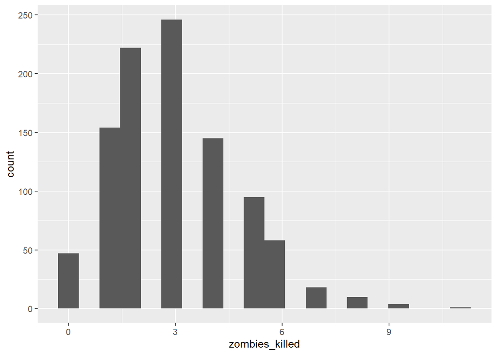

```r
ggplot(z, aes(x=zombies_killed)) + geom_histogram(bins = 20)
```

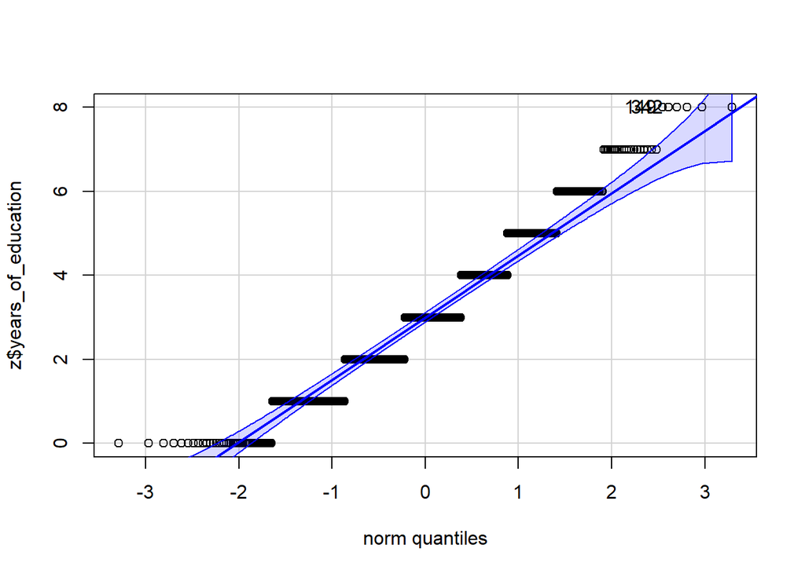

```
## [1] 149 342
```

```r
# years of education
qqPlot(z$years_of_education)
```

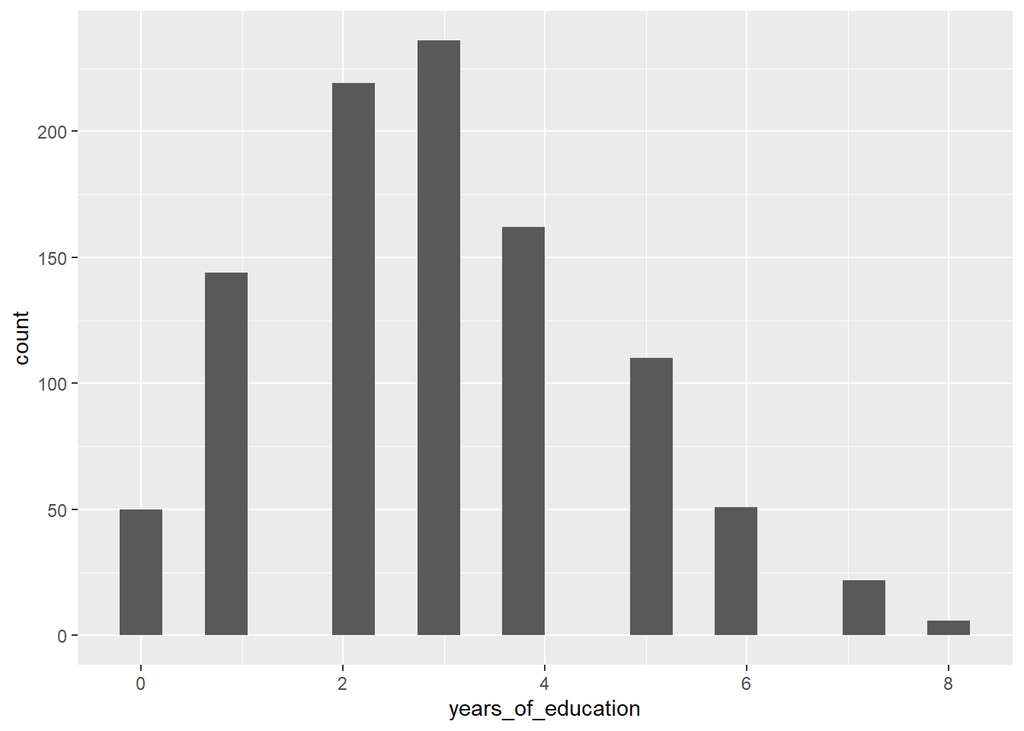

```r
ggplot(z, aes(x=years_of_education)) + geom_histogram(bins = 20)
```

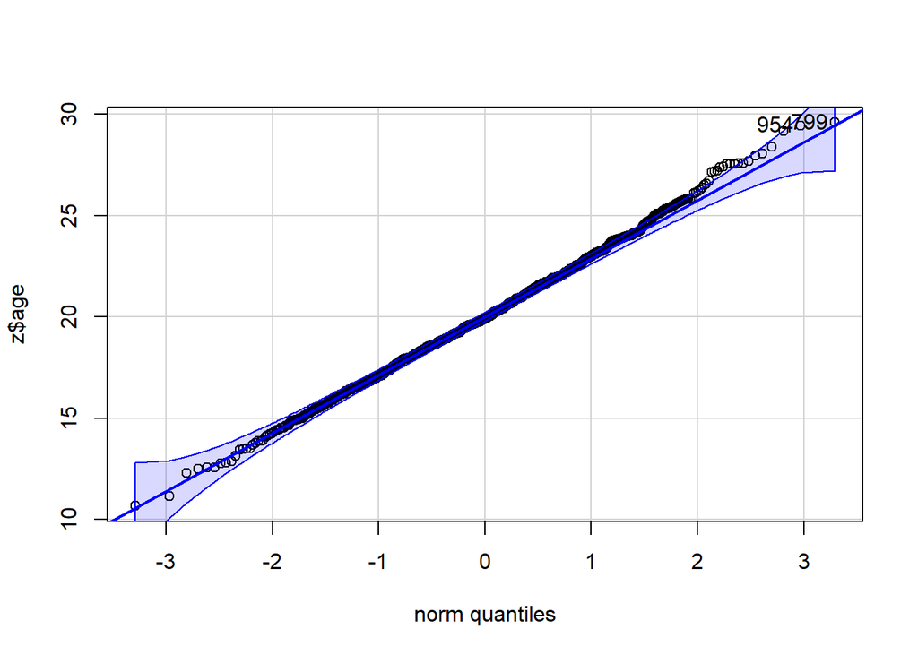

```
## [1] 799 954
```

```r
# age
qqPlot(z$age)
```

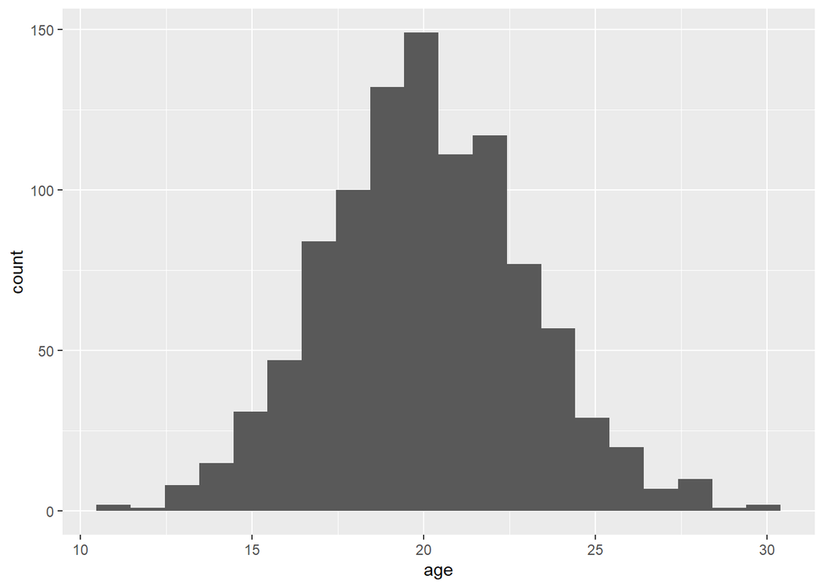

```r
ggplot(z, aes(x=age)) + geom_histogram(bins = 20)
```

## Step 6

- Now use the `sample_n()` or `slice_sample()` function from {dplyr} to sample ONE subset of 50 zombie apocalypse survivors (without replacement) from this population and calculate the mean and sample standard deviation for each variable. Also estimate the standard error for each variable based on this one sample and use that to construct a theoretical 95% confidence interval for each mean. You can use either the standard normal *or* a Student’s t distribution to derive the critical values needed to calculate the lower and upper limits of the CI.

```r
# sample of 50, with means and sd
z_sample <- z |> slice_sample(n = 50, replace = FALSE)
z_sample_summary <- z_sample |> summarize(mean.height = mean(height), sd.height = sd(height), mean.weight = mean(weight), sd.weight = sd(weight), mean.zombies = mean(zombies_killed), sd.zombies = sd(zombies_killed), mean.education = mean(years_of_education), sd.education = sd(years_of_education), mean.age = mean(age), sd.age = sd(age))
# also se
z_sample_summary$se.height <- (z_sample_summary$sd.height/sqrt(50))
z_sample_summary$se.weight <- (z_sample_summary$sd.weight/sqrt(50))
z_sample_summary$se.zombies <- (z_sample_summary$sd.zombies/sqrt(50))
z_sample_summary$se.education <- (z_sample_summary$sd.education/sqrt(50))
z_sample_summary$se.age <- (z_sample_summary$sd.age/sqrt(50))
# 95% CI for each mean (using standard normal or Student's t distribution)
CI.height <- z_sample_summary$mean.height + c(-1, 1) * qt(1 - 0.05/2, df = 49) * z_sample_summary$se.height
CI.weight <- z_sample_summary$mean.weight + c(-1, 1) * qt(1 - 0.05/2, df = 49) * z_sample_summary$se.weight
CI.zombies <- z_sample_summary$mean.zombies + c(-1, 1) * qt(1 - 0.05/2, df = 49) * z_sample_summary$se.zombies
CI.education <- z_sample_summary$mean.education + c(-1, 1) * qt(1 - 0.05/2, df = 49) * z_sample_summary$se.education
CI.age <- z_sample_summary$mean.age + c(-1, 1) * qt(1 - 0.05/2, df = 49) * z_sample_summary$se.age
```

## Step 7

- Then draw another 199 random samples of 50 zombie apocalypse survivors out of the population and calculate the mean for each of the these samples. Together with the first sample you drew out, you now have a set of 200 means for each variable (each of which is based on 50 observations), which constitutes a sampling distribution for each variable. What are the means and standard deviations of the **sampling distribution** for each variable? How do the standard deviations of the sampling distribution for each variable compare to the standard errors estimated from your first sample of size 50?

The standard deviations of 200 means are similar to the standard errors from the first sample of 50.

```r
reps <- 199
# make a sampling distribution
z_samp_dist <- z |> rep_sample_n(size = 50, reps = reps, replace = FALSE)
# summarize each replicate
z_sample_dist_summary <- z_samp_dist |> group_by(replicate) |> summarize(mean.height = mean(height), sd.height = sd(height), mean.weight = mean(weight), sd.weight = sd(weight), mean.zombies = mean(zombies_killed), sd.zombies = sd(zombies_killed), mean.education = mean(years_of_education), sd.education = sd(years_of_education), mean.age = mean(age), sd.age = sd(age))
# add first sample to the 199 samples
z_sample_dist_summary <- bind_rows(z_sample_dist_summary, z_sample_summary)
mean(z_sample_dist_summary$sd.age)
```

```
## [1] 2.967426
```

```r
sd(z_sample_dist_summary$mean.age)
```

```
## [1] 0.4229701
```

## Step 8

- Plot the sampling distributions for each variable mean. What do they look like? Are they normally distributed? What about for those variables that you concluded were not originally drawn from a normal distribution?

All of the variables have been smoothed over into what looks like normal distributions. The discrete variables (zombies killed and years of education) appear normally distributed and fit the Q-Q plots much better than before.

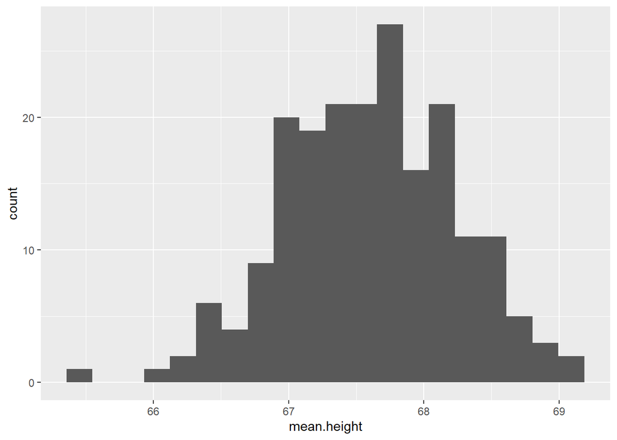

```r
ggplot(z_sample_dist_summary, aes(x = mean.height)) + geom_histogram(bins = 20)
```

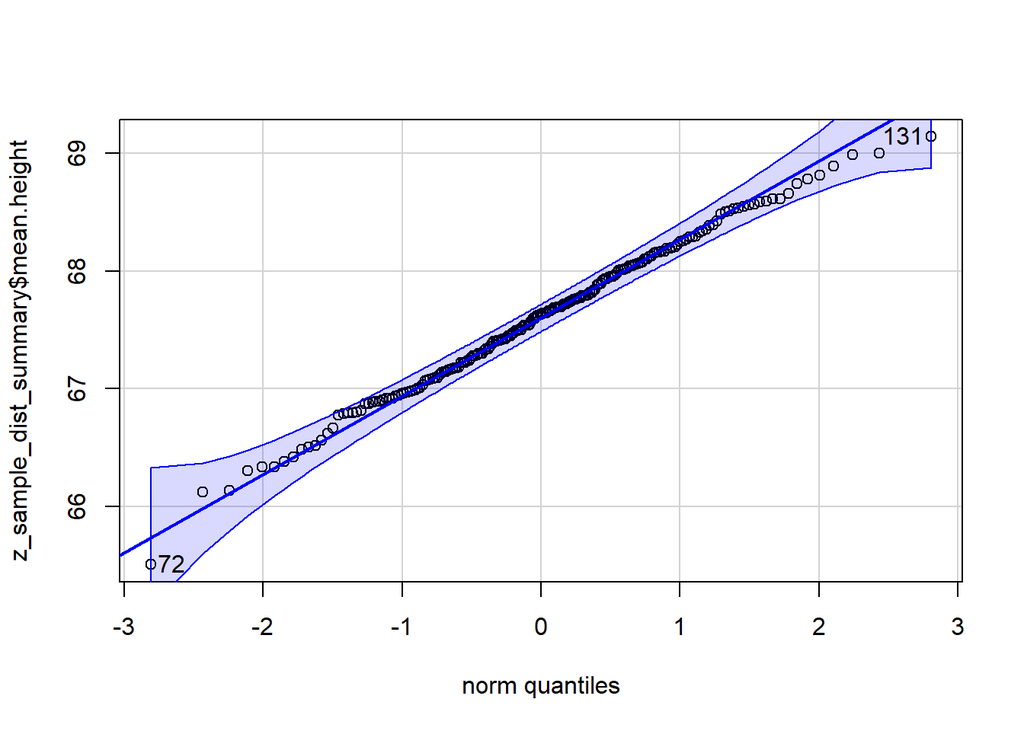

```
## [1]  72 131
```

```r
qqPlot(z_sample_dist_summary$mean.height)
```

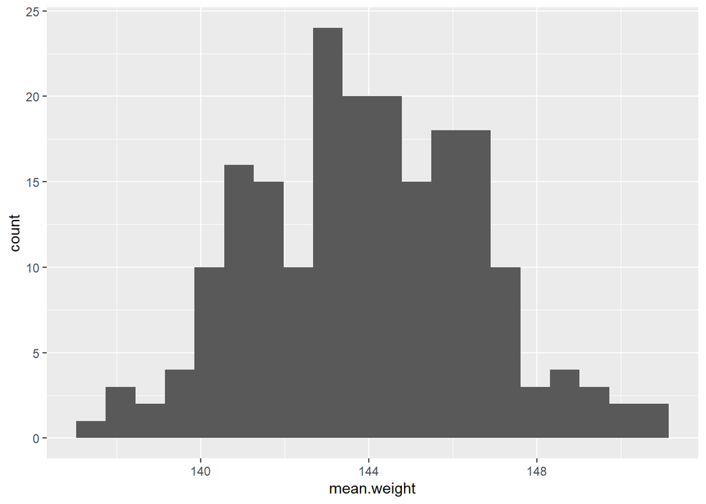

```r
ggplot(z_sample_dist_summary, aes(x = mean.weight)) + geom_histogram(bins = 20)
```

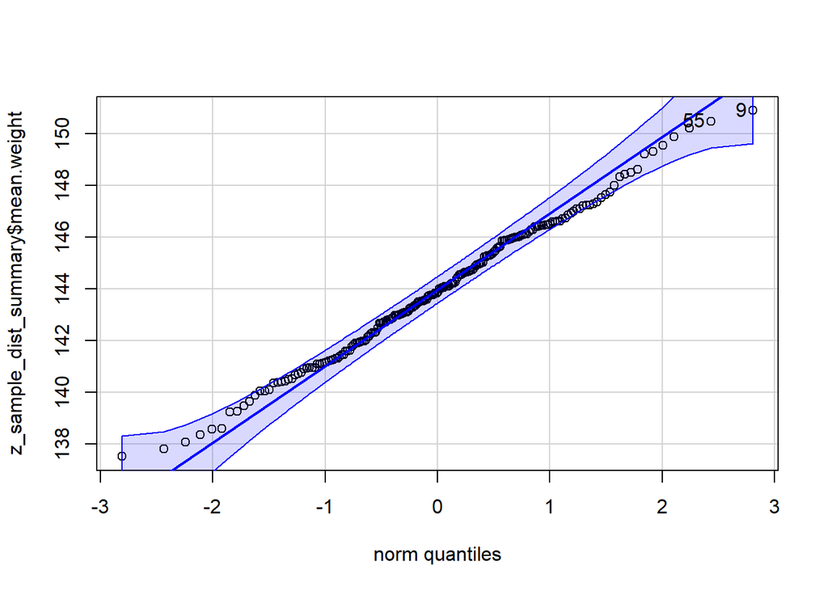

```
## [1]  9 55
```

```r
qqPlot(z_sample_dist_summary$mean.weight)
```

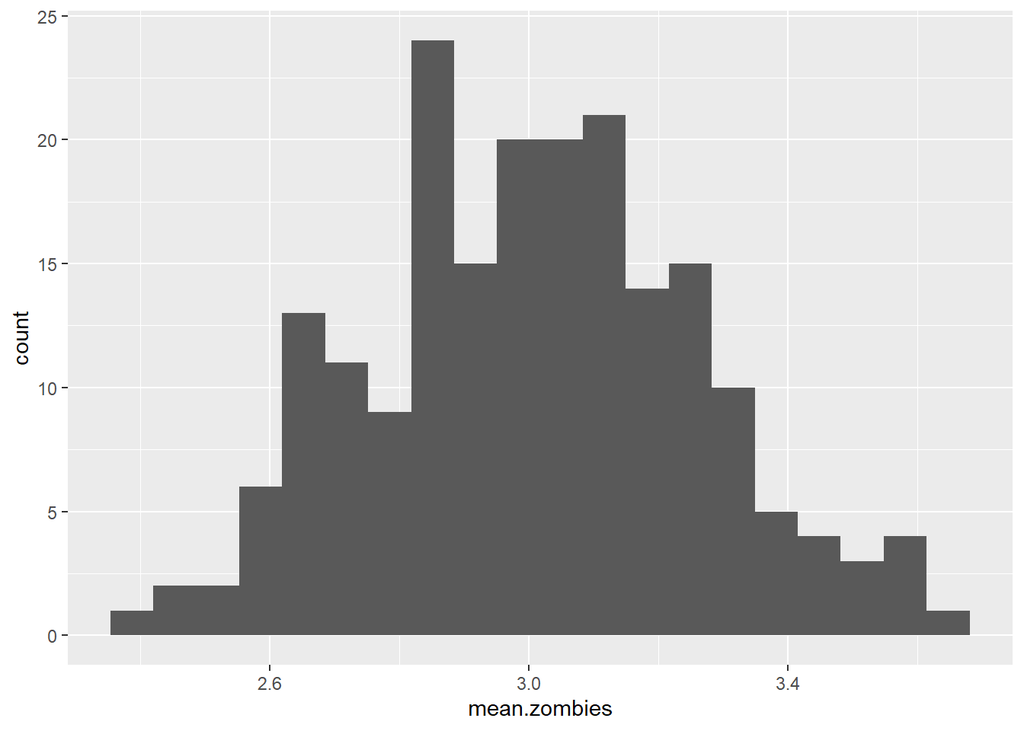

```r
ggplot(z_sample_dist_summary, aes(x = mean.zombies)) + geom_histogram(bins = 20)
```

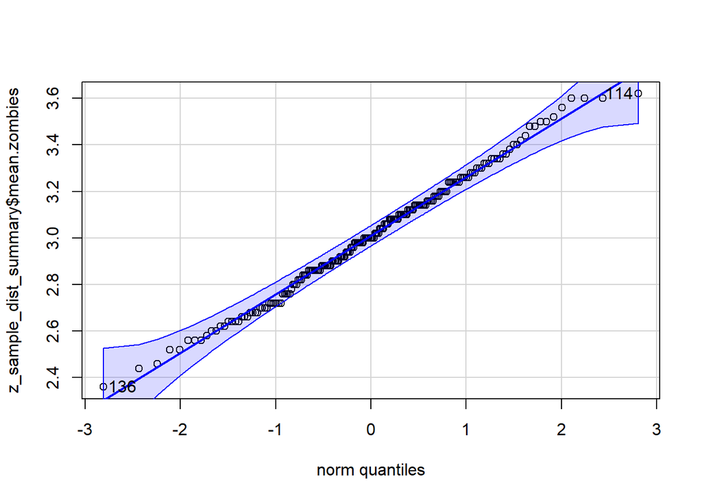

```
## [1] 136 114
```

```r
qqPlot(z_sample_dist_summary$mean.zombies)
```

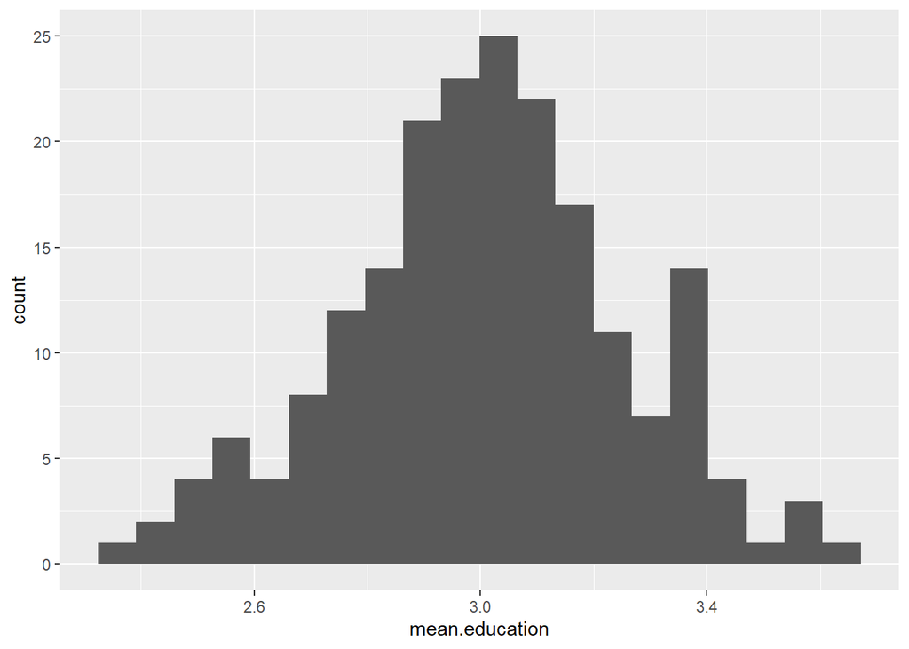

```r
ggplot(z_sample_dist_summary, aes(x = mean.education)) + geom_histogram(bins = 20)
```

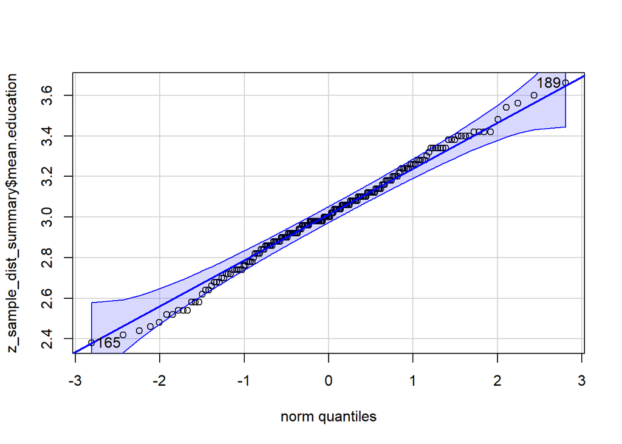

```
## [1] 189 165
```

```r
qqPlot(z_sample_dist_summary$mean.education)
```

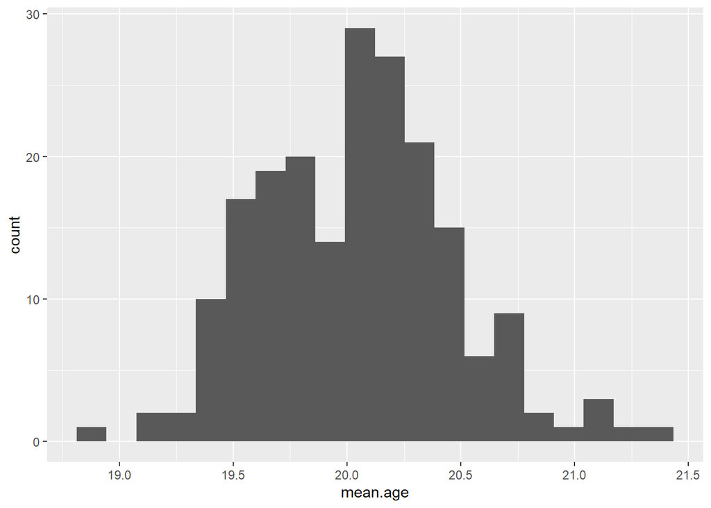

```r
ggplot(z_sample_dist_summary, aes(x = mean.age)) + geom_histogram(bins = 20)
```

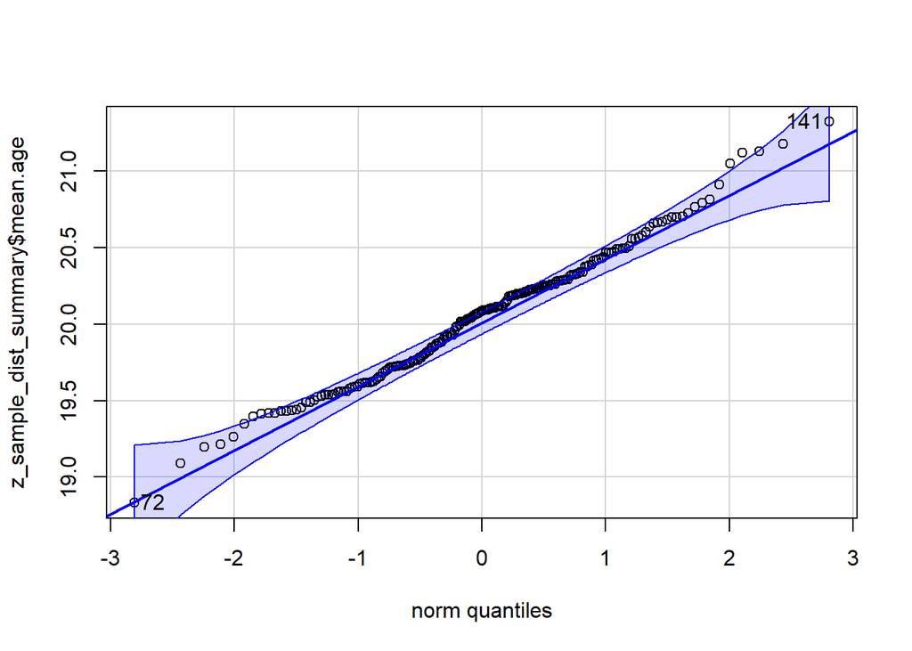

```
## [1] 141  72
```

```r
qqPlot(z_sample_dist_summary$mean.age)
```

## Step 9

- Construct a 95% confidence interval for each mean **directly from the sampling distribution** of sample means using the central 95% that distribution (i.e., by setting the lower and upper CI bounds to 2.5% and 97.5% of the way through that distribution).

> **HINT**: You will want to use the `quantile()` function for this!

How do the various 95% CIs you estimated compare to one another (i.e., the CI based on one sample and the corresponding sample standard deviation versus the CI based on simulation where you created a sampling distribution across 200 samples)?

```r
CI.dist.height <- quantile(z_sample_dist_summary$mean.height, c(0.025, 0.975))
CI.dist.weight <- quantile(z_sample_dist_summary$mean.weight, c(0.025, 0.975))
CI.dist.zombies <- quantile(z_sample_dist_summary$mean.zombies, c(0.025, 0.975))
CI.dist.education <- quantile(z_sample_dist_summary$mean.education, c(0.025, 0.975))
CI.dist.age <- quantile(z_sample_dist_summary$mean.age, c(0.025, 0.975))
```

## Step 10

- Finally, use bootstrapping to generate a 95% confidence interval for each variable mean **by resampling 1000 samples, with replacement, from your original sample** (i.e., by setting the lower and upper CI bounds to 2.5% and 97.5% of the way through the sampling distribution generated by bootstrapping).

```r
n_boot <- 1000
boot <- vector(length = n_boot)
n <- length(z_sample)
# the size of each bootstrap sample should equivalent to the size our original
# sample
for (i in 1:n_boot) {
    boot[[i]] <- mean(sample(z_sample$age, n, replace = TRUE))
}
lower_boot <- quantile(boot, 0.025)
upper_boot <- quantile(boot, 0.975)
```